# Exercise week 7

Shawn Schneidereit

2021-06-03

### 8H1 Return to the data(tulips) example in the chapter. Now include the bed variable as a pre- dictor in the interaction model. Don’t interact bed with the other predictors; just include it as a main effect. Note that bed is categorical. So to use it properly, you will need to either construct dummy variables or rather an index variable, as explained in Chapter 5.

```r
data(tulips, package = "rethinking")
d <- tulips
rm(tulips)

head(d)
```

```
##   bed water shade blooms
## 1   a     1     1   0.00
## 2   a     1     2   0.00
## 3   a     1     3 111.04
## 4   a     2     1 183.47
## 5   a     2     2  59.16
## 6   a     2     3  76.75
```

```r
d <-
  d %>%
  mutate(blooms_std = blooms / max(blooms),
         water_cent = water - mean(water),
         shade_cent = shade - mean(shade))

b8 <-
  brm(data = d,
      family = gaussian,
      blooms_std ~ 1 + water_cent + shade_cent + water_cent:shade_cent,
      prior = c(prior(normal(0.5, 0.25), class = Intercept),
                prior(normal(0, 0.25), class = b, coef = water_cent),
                prior(normal(0, 0.25), class = b, coef = shade_cent),
                prior(exponential(1), class = sigma)),
      iter = 2000, warmup = 1000, chains = 4, cores = 4,
      seed = 42)

b8.1 <-
  brm(
    data = d,
    family = gaussian,
    blooms_std ~ 0 + bed + water_cent + shade_cent + water_cent:shade_cent,
    prior = c(
      #prior(normal(0.5, 0.25), class = Intercept),
      prior(normal(0, 0.25), class = b, coef = water_cent),
      prior(normal(0, 0.25), class = b, coef = shade_cent),
      prior(normal(0, 0.25), class = b, coef = "water_cent:shade_cent"),
      prior(exponential(1), class = sigma)
    ),
    iter = 2000,
    warmup = 1000,
    chains = 4,
    cores = 4,
    seed = 42
  )
```

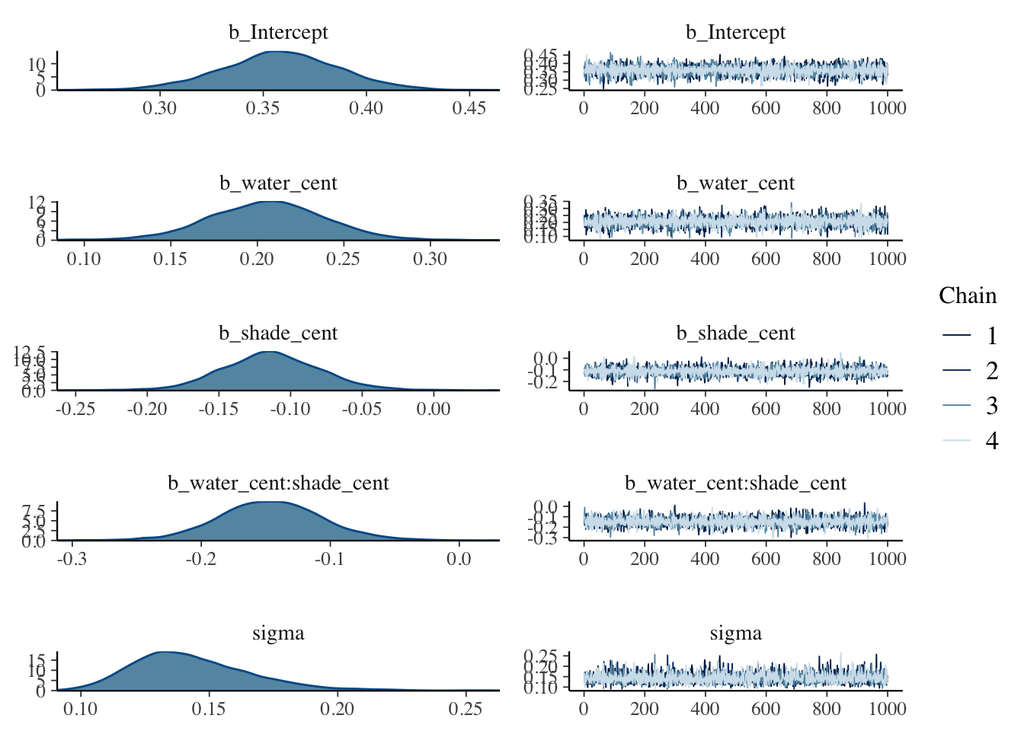

```r
plot(b8)
```

```r
summary(b8)
```

```
##  Family: gaussian
##   Links: mu = identity; sigma = identity
## Formula: blooms_std ~ 1 + water_cent + shade_cent + water_cent:shade_cent
##    Data: d (Number of observations: 27)
## Samples: 4 chains, each with iter = 2000; warmup = 1000; thin = 1;
##          total post-warmup samples = 4000
##
## Population-Level Effects:
##                       Estimate Est.Error l-95% CI u-95% CI Rhat Bulk_ESS
## Intercept                 0.36      0.03     0.30     0.41 1.00     4907
## water_cent                0.21      0.03     0.14     0.27 1.00     5021
## shade_cent               -0.11      0.03    -0.18    -0.04 1.00     4696
## water_cent:shade_cent    -0.15      0.04    -0.23    -0.07 1.00     4992
##                       Tail_ESS
## Intercept                 2624
## water_cent                2615
## shade_cent                2707
## water_cent:shade_cent     2992
##
## Family Specific Parameters:
##       Estimate Est.Error l-95% CI u-95% CI Rhat Bulk_ESS Tail_ESS
## sigma     0.14      0.02     0.11     0.20 1.00     3560     3135
##
## Samples were drawn using sampling(NUTS). For each parameter, Bulk_ESS
## and Tail_ESS are effective sample size measures, and Rhat is the potential
## scale reduction factor on split chains (at convergence, Rhat = 1).
```

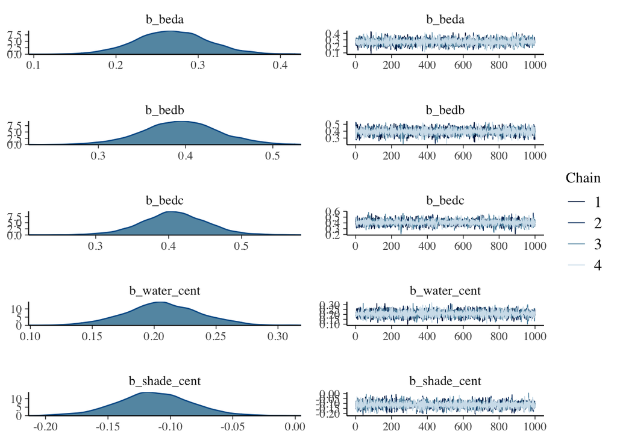

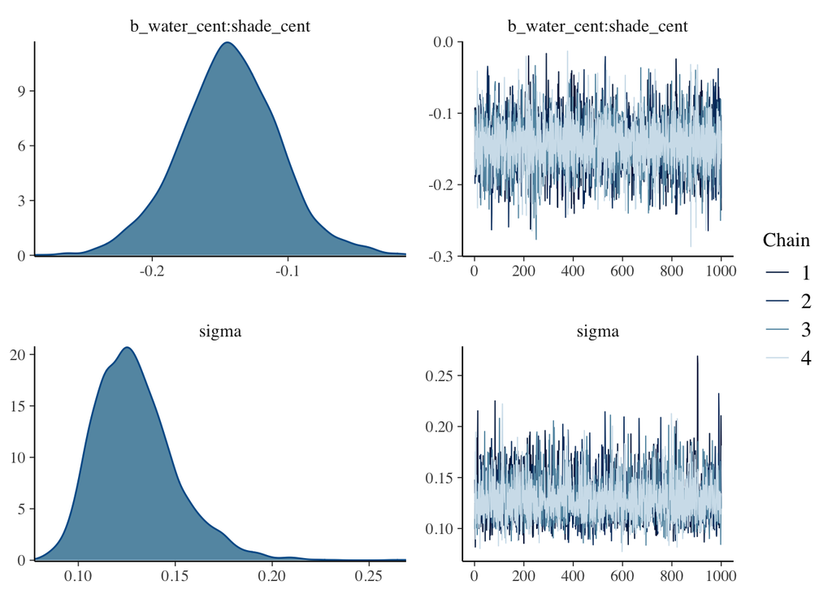

```r
plot(b8.1)
```

```r
summary(b8.1)
```

```
##  Family: gaussian
##   Links: mu = identity; sigma = identity
## Formula: blooms_std ~ 0 + bed + water_cent + shade_cent + water_cent:shade_cent
##    Data: d (Number of observations: 27)
## Samples: 4 chains, each with iter = 2000; warmup = 1000; thin = 1;
##          total post-warmup samples = 4000
##
## Population-Level Effects:
##                       Estimate Est.Error l-95% CI u-95% CI Rhat Bulk_ESS
## beda                      0.27      0.04     0.18     0.36 1.00     6804
## bedb                      0.39      0.04     0.31     0.48 1.00     7403
## bedc                      0.41      0.04     0.32     0.50 1.00     5996
## water_cent                0.21      0.03     0.15     0.27 1.00     6204
## shade_cent               -0.11      0.03    -0.17    -0.05 1.00     5970
## water_cent:shade_cent    -0.14      0.04    -0.22    -0.07 1.00     5590
##                       Tail_ESS
## beda                      2839
## bedb                      3064
## bedc                      2799
## water_cent                3060
## shade_cent                3033
## water_cent:shade_cent     2945
##
## Family Specific Parameters:
##       Estimate Est.Error l-95% CI u-95% CI Rhat Bulk_ESS Tail_ESS
## sigma     0.13      0.02     0.10     0.18 1.00     3456     3112
##
## Samples were drawn using sampling(NUTS). For each parameter, Bulk_ESS
## and Tail_ESS are effective sample size measures, and Rhat is the potential
## scale reduction factor on split chains (at convergence, Rhat = 1).
```

### 8H2 Use WAIC to compare the model from 8H1 to a model that omits bed. What do you infer from this comparison? Can you reconcile the WAIC results with the posterior distribution of the bed coefficients?

```r
b8 <- add_criterion(b8, criterion = "waic")
b8.1 <- add_criterion(b8.1, criterion = "waic")
b_waic <- loo_compare(b8, b8.1, criterion = "waic")

print(b_waic, simplify = F)
```

```
##      elpd_diff se_diff elpd_waic se_elpd_waic p_waic se_p_waic waic  se_waic
## b8.1   0.0       0.0    14.0       3.3          6.0    1.3     -28.1   6.5
## b8    -1.6       2.8    12.4       3.8          4.3    1.1     -24.9   7.5
```

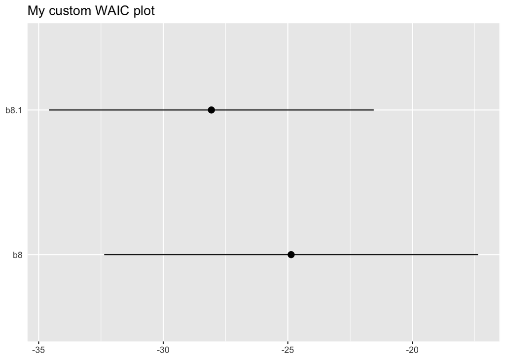

```r
b_waic[, 7:8] %>%
  data.frame() %>%
  rownames_to_column("model_name") %>%
  mutate(model_name = fct_reorder(model_name, waic, .desc = T)) %>%

  ggplot(aes(x = waic, y = model_name,
             xmin = waic - se_waic,
             xmax = waic + se_waic)) +
  geom_pointrange() +
  labs(title = "My custom WAIC plot",
       x = NULL, y = NULL) +
  theme(axis.ticks.y = element_blank())
```

Can you reconcile the WAIC results with the posterior distribution of the bed coefficients?

From the comparison of the models WAIC we can infer that adding bed to the model provides more valuable information content, than predictive ability that is lossed through overfitting. When comparing the WAICs we can also see that overall the difference between two models is not huge though and there still considerable uncertainty.

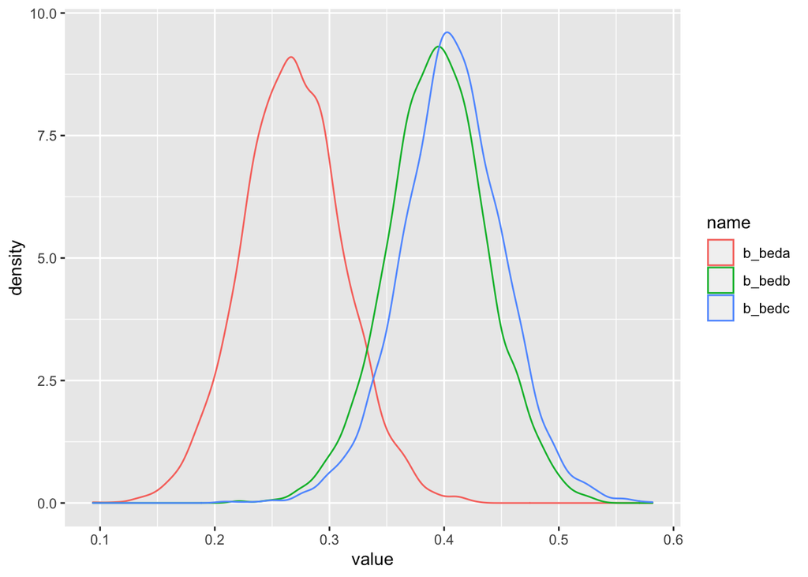

```r
psamp <- posterior_samples(b8.1)[,1:3] %>%
  pivot_longer(cols = everything())
ggplot(psamp) +
  geom_density(mapping = aes(x = value, group = name, col = name))
```

Yes the WAIC results can partially reconciled with the posterior distributions. bed a seperates nicely but there overlap and thus uncertainly between b and C, limiting the overall value of including bed into the model